# FRVT Paperless Travel

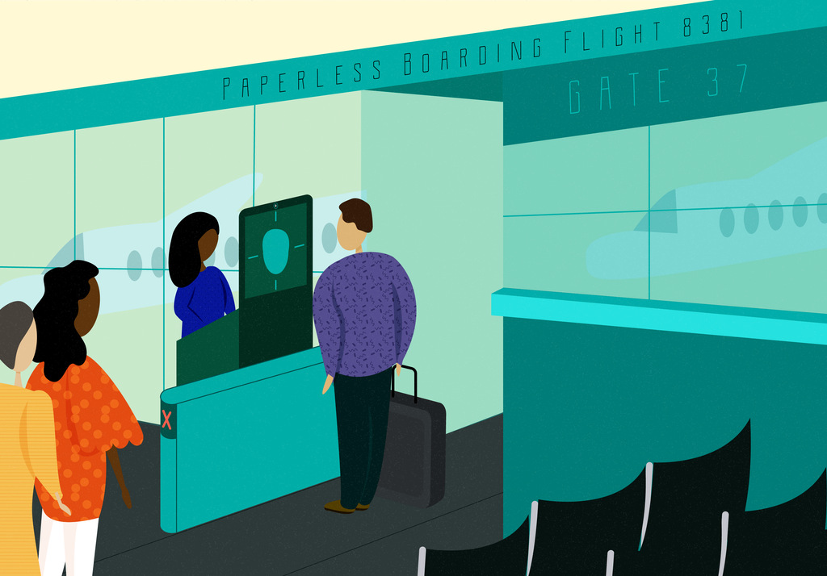

Credit: Natasha Hanacek/NIST

[Latest Report](https://pages.nist.gov/frvt/reports/travel/frvt_travel_report.pdf) | [Algorithm Submission](https://pages.nist.gov/frvt/html/frvt1N.html)

**[2021-07-13]** We have released a new report from the Face Recognition Vendor Test (FRVT) program: *Part 7: Identification for Paperless Travel and Immigration*. As described in this [press release](https://www.nist.gov/news-events/news/2021/07/nist-evaluates-face-recognition-softwares-accuracy-flight-boarding), the report describes the paperless travel application, details the kinds of biometric errors that can occur, and includes extensive results from simulations of face recognition for boarding an aircraft and traversing an airport security point.

The report will be updated on a regular basis as new analyses are implemented, and as results for newly submitted FRVT algorithms are produced.

One-to-many facial recognition is being used in airport transit settings with a traveler’s face being matched against galleries of individuals expected to be present. This allows, for example, the traditional boarding pass to be replaced with the presentation of a biometric - the face - to a camera. During aircraft boarding, the biometric is serving a double role, first for access control to an aircraft and, second, for facilitation of a visa holder recording their departure from a country.

**[2023-07-03]** The table below shows the False Negative Identification Rates - “miss rates” - as the percentage of travelers not matched to their gallery photo(s). This is done where a threshold is set to limit the False Positive Identification Rate (FPIR) to 0.0003. In this leaderboard, the 420 person galleries represent aircraft boarding while the 42000-person trial represents a centralized airport security line where many more people are expected in a given temporal window. The k value represents the number of images of each enrollee in each gallery.

| Algorithm | Developer | Submission Date | Template Time (msec) | Percent Travelers Not MatchedN = 420k ≥ 1 | Percent Travelers Not MatchedN = 420k = 1 | Percent Travelers Not MatchedN = 42000k = 1 |
| --- | --- | --- | --- | --- | --- | --- |
| sensetime-007 | Sensetime Group (CN) | 2022-01-15 | _ | 0.02(1) | 0.07(1) | 0.23(1) |
| visionlabs-010 | VisionLabs (RU) | 2021-02-05 | _ | 0.02(2) | 0.13(8) | 0.61(14) |
| hyperverge-002 | HyperVerge Inc (IN) | 2022-04-13 | _ | 0.02(3) | 0.13(9) | 0.51(11) |
| sensetime-006 | Sensetime Group (CN) | 2021-07-26 | _ | 0.02(4) | 0.08(2) | 0.35(6) |
| neurotechnology-012 | Neurotechnology (LT) | 2022-06-07 | _ | 0.02(5) | 0.11(5) | 0.65(15) |
| cloudwalk-mt-000 | Cloudwalk Moontime Smart Technology (CN) | 2022-01-31 | _ | 0.02(6) | 0.11(4) | 0.23(2) |
| paravision-009 | Paravision (US) | 2021-12-14 | _ | 0.02(7) | 0.09(3) | 0.32(4) |
| hyperverge-001 | HyperVerge Inc (IN) | 2021-08-17 | _ | 0.02(8) | 0.16(14) | 0.60(13) |
| idemia-008 | Idemia (FR) | 2021-03-15 | _ | 0.02(9) | 0.15(11) | 0.49(9) |
| clearviewai-000 | Clearview AI Inc (US) | 2021-11-12 | _ | 0.03(10) | 0.16(13) | 0.71(16) |

[output cut: 45 more lines]

All prior Ongoing FRVT Paperless Travel reports can be accessed from [here](https://github.com/usnistgov/frvt/tree/nist-pages/reports/travel/).

Inquiries and comments may be submitted to frvt@nist.gov.

Subscribe to the FRVT mailing list to receive emails when announcements or updates are made.

## Related NIST Projects

##### [FRVT Ongoing](https://www.nist.gov/programs-projects/face-recognition-vendor-test-frvt-ongoing)

##### [FRVT 1:N Identification](https://pages.nist.gov/frvt/html/frvt1N.html)

##### [FRVT 1:1 Verification](https://pages.nist.gov/frvt/html/frvt11.html)

##### [FRVT Demographic Effects](https://pages.nist.gov/frvt/html/frvt_demographics.html)

##### [FRVT MORPH](https://pages.nist.gov/frvt/html/frvt_morph.html)

##### [FRVT Quality](https://pages.nist.gov/frvt/html/frvt_quality.html)

##### [FRVT Face Mask Effects](https://pages.nist.gov/frvt/html/frvt_facemask.html)

##### [FRVT PAD](https://pages.nist.gov/frvt/html/frvt_pad.html)

##### [FRVT Twins Demonstration](https://pages.nist.gov/frvt/html/frvt_twins_demonstration.html)

##### [FRVT Age Estimation](https://pages.nist.gov/frvt/html/frvt_age_estimation.html)